# Assignment_1_CAP3330_Fall26

Create an R notebook to answer the questions presented below.

### **Question 1** (40 points)

A researcher wants to compare the average anxiety levels of people living in Alaska and Hawaii. The researcher does not have any specific hypothesis in mind in terms of which state could have higher mean anxiety levels. She collected anxiety scores for two random samples of residents, one from each state. Each resident was given a score between 0 to 100 (higher scores mean more anxiety).

The anxiety scores she collected for each state are shown next. Create two vectors in R with these data (one vector for Alaska scores and another one for Hawaii scores).

Alaska scores:  
69 76 64 65 67 77 56 67 62 82 56 77 71 68 76 69 64 66 83 77 75 79 71 75 86 67 70 73 77 71 78 64 62 58 67

Hawaii scores:  
64 76 74 74 73 71 75 63 67 77 74 67 69 70 64 72 72 72 74 76 67 69 80 73 68 77 71 73 69 68 71 71 73 75 71

create these two vectors

```r
alaska <- c(69,76,64,65,67,77,56,67,62,82,56,77,71,68,76,69,64,66,83,77,
            75,79,71,75,86,67,70,73,77,71,78,64,62,58,67)
hawaii <- c(64,76,74,74,73,71,75,63,67,77,74,67,69,70,64,72,72,72,74,76,
            67,69,80,73,68,77,71,73,69,68,71,71,73,75,71)
```

**a) (15 points) Run an exploratory analysis relevant to the question addressed by this researcher. The analysis must include computing summary stats and doing one plot. Also, and most importantly, interpret the results of the exploratory analysis.**

**Requirement: You MUST do the exact same exploratory analysis we did in class. If you do something different (e.g., use different R functions, compute different summary stats, do different plots, etc than the ones we used in class), you will receive ZERO points for this part with the following comment: Intentionally failed to follow the instructions.**

```r
length(alaska)
```

```
## [1] 35
```

```r
length(hawaii)
```

```
## [1] 35
```

Create a data frame containing the anxiety scores and the corresponding state.

```r
anxiety_scores_df <- data.frame(
  anxiety_score = c(alaska, hawaii),
  state = c(rep("Alaska", length(alaska)),
            rep("Hawaii", length(hawaii)))
)
```

```r
anxiety_scores_df |> str()
```

```
## 'data.frame':    70 obs. of  2 variables:
##  $ anxiety_score: num  69 76 64 65 67 77 56 67 62 82 ...
##  $ state        : chr  "Alaska" "Alaska" "Alaska" "Alaska" ...
```

Obtain mean, median, and standard deviation of the anxiety scores for each state. Round these numbers to 1 decimal place.

```r
anxiety_scores_df |>
  group_by(state) |>
  summarise(
    mean = round(mean(anxiety_score), 1),
    median = round(median(anxiety_score), 1),
    sd = round(sd(anxiety_score), 1)
  )
```

```
## # A tibble: 2 × 4
##   state   mean median    sd
##   <chr>  <dbl>  <dbl> <dbl>
## 1 Alaska  70.4     70   7.5
## 2 Hawaii  71.4     72   3.9
```

Do a box plot of anxiety scores by state.

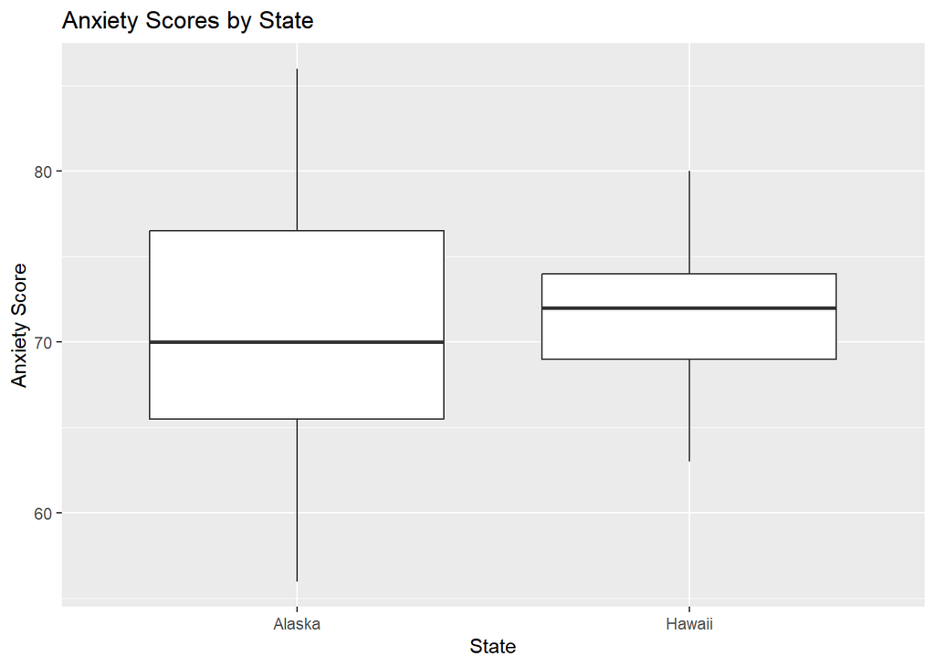

```r
anxiety_scores_df |>
  ggplot(aes(x = state, y = anxiety_score)) +
  geom_boxplot() +
  labs(
    title = "Anxiety Scores by State",
    x = "State",
    y = "Anxiety Score"
  )
```

Conclusion from the exploratory analysis:

The exploratory analysis suggests that anxiety levels are relatively similar in Alaska and Hawaii. However, Hawaii has a slightly higher mean anxiety score (71.4) and median anxiety score (72) compared to Alaska (mean = 70.4, median = 70). The standard deviation is larger for Alaska (7.5) than for Hawaii (3.9), indicating that anxiety scores are more variable among Alaska residents.

The boxplot shows that the distributions of anxiety scores for the two states overlap considerably, although the center of the Hawaii distribution appears to be slightly higher. The plot also indicates greater spread in the Alaska scores, which is consistent with the larger standard deviation.

Therefore, the exploratory analysis provides some evidence that Hawaii residents may have slightly higher average anxiety levels than Alaska residents, but the observed difference appears to be small. A statistical test is needed to determine whether this difference is statistically significant.

**b) (5 points) If the researcher decides to run a hypothesis test to complement her conclusion from a), state the hypotheses (Ho and Ha) that she should set up to conduct the test that will allow her to make the desired comparison.**

Version 1

- Ho: μAlaska = μHawaii
- Ha: μAlaska ≠ μHawaii

Version 2

- Ho: The mean anxiety score of Alaska residents is equal to the mean anxiety score of Hawaii residents.
- Ha: The mean anxiety score of Alaska residents is different from the mean anxiety score of Hawaii residents.

**c) (15 points) Run the corresponding statistical test and make a decision and conclude using a significance level of 0.05. Justify your decision.**

Test for Equality of Variances

```r
var.test(alaska, hawaii, alternative = "two.sided")
```

```
##
##  F test to compare two variances
##
## data:  alaska and hawaii
## F = 3.6078, num df = 34, denom df = 34, p-value = 0.0003212
## alternative hypothesis: true ratio of variances is not equal to 1
## 95 percent confidence interval:
##  1.821114 7.147568
## sample estimates:
## ratio of variances
##           3.607843
```

Decision: The p-value (0.0003212) is less than the significance level α = 0.05; therefore, we reject Ho and support Ha.

Conclusion: The data provide sufficient evidence to conclude that the variances of anxiety scores in Alaska and Hawaii are different. Therefore, the assumption of equal variances is not appropriate, and the Welch Two Sample t-test (var.equal = FALSE) should be used for comparing the means.